# briana-sealey-ADA-data-reanalysis-assignment

Briana Sealey

4/6/2020

## Introduction

There is imperfection in an animal’s ability to perceive physical reality and their cognitive processes and this inconsistency can lead to incorrect assessments in prey choice. Specifically, proportional processing, the ability to assess differences between quantities, can be constrained. This was tested in *Trachops cirrhosus*, given various quantities of frog choruses. Bats genreally preferred larger chorus sizes, but failed to discern the differences in frog chorus sizes in trails between larger choruses (i.e. choruses of 5 and 6 frogs) vs. smaller ones (i.e. 1 and 2 frogs). Thus, this experiment determined that *T. cirrhosus* rely on the relative differences and not the absolute differences in choruses and may be less persnickety when foraging in larger chorusing groups of frogs.

## Visualization of Data

#### Replicating Figure 2.

```r
#load packages necessary to complete analysis
library(lme4)
library(readr)
library(dplyr)
library(ggplot2)
library(ggthemes)
library(gridExtra)
library(AICcmodavg)
```

```r
#read in data
d <- "Hemingway et al._2018_data.csv"
data <- read_csv(d, col_names = TRUE) #reading in the data
#Taking a look at the data-set
names(data)
```

```
##  [1] "Animal"    "Order"     "Treatment" "Choice"    "Larger"    "LoR"
##  [7] "Reward"    "Latency"   "AbsDiff"   "Ratio"     "RelDiff"
```

```r
head(data, 10)
```

```
## # A tibble: 10 x 11
##    Animal Order Treatment Choice Larger   LoR Reward Latency AbsDiff Ratio
##    <chr>  <int> <chr>      <int>  <int> <int>  <int>   <dbl>   <int> <dbl>
##  1 C          1 1v2            1      0     0      1    1.78       1   0.5
##  2 D          1 1v2            1      0     0      1    1.26       1   0.5
##  3 F          1 1v2            1      0     1      1    1.61       1   0.5
##  4 J          2 1v2            1      0     1      1    2.99       1   0.5
##  5 A          1 1v2            2      1     0      0   14.4        1   0.5
##  6 B          1 1v2            2      1     1      0    2.5        1   0.5
##  7 E          1 1v2            2      1     0      0    1.1        1   0.5
##  8 G          1 1v2            2      1     0      1    8.09       1   0.5
##  9 H          1 1v2            2      1     0      0    2.64       1   0.5
## 10 I          1 1v2            2      1     1      0    0.83       1   0.5
## # … with 1 more variable: RelDiff <dbl>
```

```r
#Calculate absolute and relative differences (absolute diff/mean(number of calls of the twos stimuli)) between chrous size
data %>%
  group_by(Treatment) %>%
  summarise(abs = mean(AbsDiff), rel = mean(RelDiff), prop = sum(Larger)/n()) -> plt
plt
```

```
## # A tibble: 15 x 4
##    Treatment   abs   rel  prop
##    <chr>     <dbl> <dbl> <dbl>
##  1 1v2           1 0.67  0.882
##  2 1v3           2 1     0.912
##  3 1v4           3 1.2   0.824
##  4 1v5           4 1.33  0.824
##  5 1v6           5 1.43  0.794
##  6 2v3           1 0.4   0.824
##  7 2v4           2 0.67  0.618
##  8 2v5           3 0.857 0.647
##  9 2v6           4 1     0.714
## 10 3v4           1 0.290 0.471
## 11 3v5           2 0.5   0.706
## 12 3v6           3 0.67  0.676
## 13 4v5           1 0.22  0.647
## 14 4v6           2 0.4   0.735
## 15 5v6           1 0.19  0.529
```

Graph from the article:

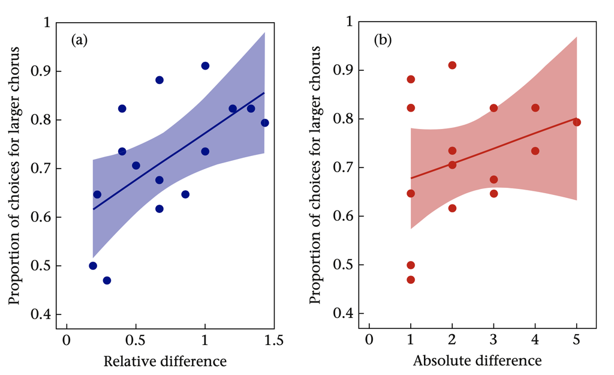

Figure 2. Visualization of the proportion of choices made by the bats versus the difference between the two choices presented.

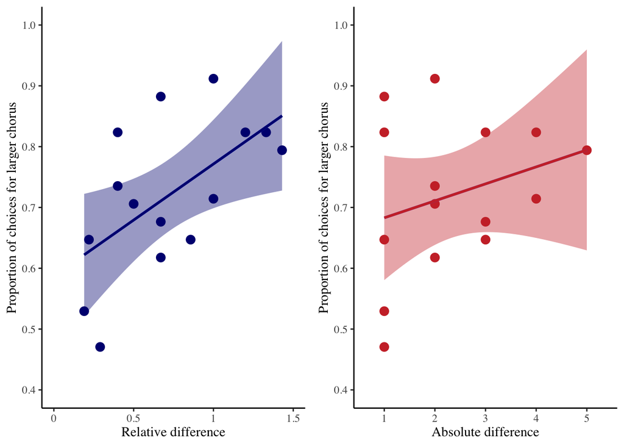

```r
#Linear regression graphs
theme_set(theme_tufte()) #setting theme for plotting graphs

#joke's on me, I couldn't figure out how to get the confidence intervals to show correctly in base r, so I switched to ggplot(). Bri: 0, ggplot(): 1.

#Graphing Abs Diff
p1 <- ggplot(plt, aes(x = abs, y = prop)) +
  geom_point(color = 'brown3', size = 3) +
  geom_smooth(method = lm, fill = 'brown3') +
  geom_smooth(method = lm, color = 'brown3', se = FALSE) +
  ylab(label = "Proportion of choices for larger chorus") +
  xlab(label = "Absolute difference") +
  theme(axis.line = element_line(colour = "black")) +
  scale_x_discrete(label = c("1","2","3","4","5","6"),limits = c("1","2","3","4","5","6")) +
  scale_y_continuous(limits = c(0.4, 1), breaks = c(0.4,0.5,0.6,0.7,0.8,0.9, 1.0),
                     label = c("0.4","0.5","0.6","0.7","0.8","0.9", "1.0"))

#Graphing Rel Diff
p2 <- ggplot(plt, aes(x = rel, y = prop)) +
  geom_point(color = 'navy', size = 3) +
  geom_smooth(method = lm, fill = 'navy') +
  geom_smooth(method = lm, color = 'navy', se = FALSE) +
  ylab(label = "Proportion of choices for larger chorus") +
  xlab(label = "Relative difference") +
  theme(axis.line = element_line(colour = "black")) +
  scale_x_continuous(label = c("0","0.5","1","1.5"), limits = c(0,1.5), breaks = c(0,0.5,1,1.5)) +
  scale_y_continuous(limits = c(0.4, 1), breaks = c(0.4,0.5,0.6,0.7,0.8,0.9, 1.0),
                     label = c("0.4","0.5","0.6","0.7","0.8","0.9", "1.0"))
grid.arrange(p2, p1, ncol = 2, nrow = 1)
```

```r
#taking a look at the estimates for both
lm1 <- lm(prop ~ abs, data = plt)
summary(lm1)
```

```
##
## Call:
## lm(formula = prop ~ abs, data = plt)
##
## Residuals:
##       Min        1Q    Median        3Q       Max
## -0.212365 -0.077011 -0.004982  0.070798  0.200900
##
## Coefficients:
##             Estimate Std. Error t value Pr(>|t|)
## (Intercept)  0.65504    0.06872   9.533 3.13e-07 ***
## abs          0.02791    0.02597   1.075    0.302
## ---
## Signif. codes:  0 '***' 0.001 '**' 0.01 '*' 0.05 '.' 0.1 ' ' 1
##
## Residual standard error: 0.1255 on 13 degrees of freedom
## Multiple R-squared:  0.08159,    Adjusted R-squared:  0.01094
## F-statistic: 1.155 on 1 and 13 DF,  p-value: 0.3021
```

```r
lm2 <- lm(prop ~ rel, data = plt)
summary(lm2) #This was not presented within the paper, but provided here to display quantitative differences between the two graphs.
```

```
##
## Call:
## lm(formula = prop ~ rel, data = plt)
##
## Residuals:
##       Min        1Q    Median        3Q       Max
## -0.169943 -0.074934 -0.008808  0.050548  0.171738
##
## Coefficients:
##             Estimate Std. Error t value Pr(>|t|)
## (Intercept)  0.58705    0.05778  10.160  1.5e-07 ***
## rel          0.18443    0.07051   2.616   0.0214 *
## ---
## Signif. codes:  0 '***' 0.001 '**' 0.01 '*' 0.05 '.' 0.1 ' ' 1
##
## Residual standard error: 0.106 on 13 degrees of freedom
## Multiple R-squared:  0.3448, Adjusted R-squared:  0.2944
## F-statistic: 6.842 on 1 and 13 DF,  p-value: 0.02136
```

## Replications/Reanalysis

Replicated:

- The proportion of choices observed in bats throughout treatment levels
- Binomial tests (probability of success & p-values)
- Linear regression graph (shown above)
- Replicating binomial generalized linear mixed-effect models

#### Replicating calculcation of proportion of choices observed in each treatment level

```r
#Obtaining proportion of choices observed
data %>%
  group_by(Treatment) %>%
  summarise(proportion = sum(Larger)/n()) -> proportion_results #relative differences calculation = (absolute diff/mean(number of calls of the two stimuli))
proportion_results
```

```
## # A tibble: 15 x 2
##    Treatment proportion
##    <chr>          <dbl>
##  1 1v2            0.882
##  2 1v3            0.912
##  3 1v4            0.824
##  4 1v5            0.824
##  5 1v6            0.794
##  6 2v3            0.824
##  7 2v4            0.618
##  8 2v5            0.647
##  9 2v6            0.714
## 10 3v4            0.471
## 11 3v5            0.706
## 12 3v6            0.676
## 13 4v5            0.647
## 14 4v6            0.735
## 15 5v6            0.529
```

```r
#some proportions calculated above are slightly different than those reported in the data set:

Hemingway <- c(0.8824, 0.9118, 0.8235, 0.8235, 0.7941, 0.8235, 0.6176, 0.6471, 0.7353, 0.4706, 0.7059, 0.6765, 0.6471, 0.7353, 0.5000) #obtained proportions from Table 1 (below)
```

Proportions from article:

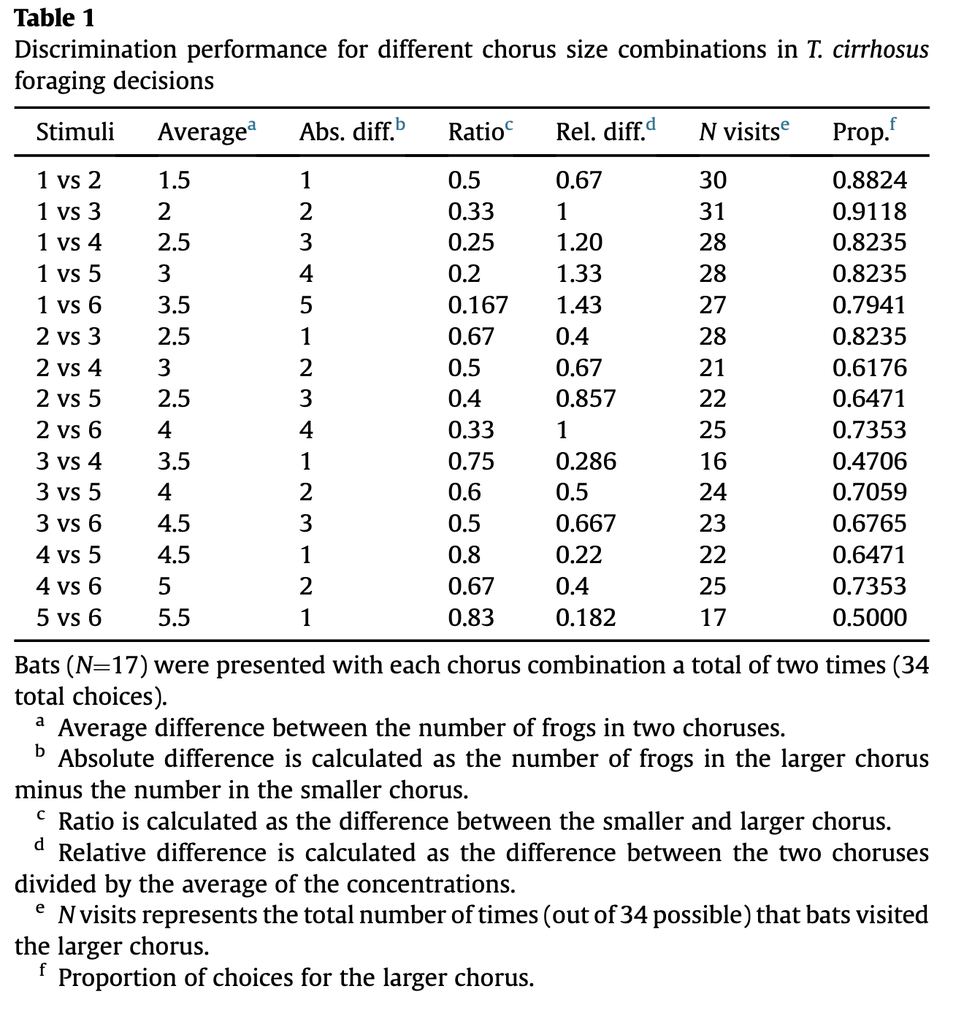

Table 1. Summary of bat choices across all trials

```r
cbind(proportion_results, Hemingway) #looking at my calculations vs. their's
```

```
##    Treatment proportion Hemingway
## 1        1v2  0.8823529    0.8824
## 2        1v3  0.9117647    0.9118
## 3        1v4  0.8235294    0.8235
## 4        1v5  0.8235294    0.8235
## 5        1v6  0.7941176    0.7941
## 6        2v3  0.8235294    0.8235
## 7        2v4  0.6176471    0.6176
## 8        2v5  0.6470588    0.6471
## 9        2v6  0.7142857    0.7353
## 10       3v4  0.4705882    0.4706
## 11       3v5  0.7058824    0.7059
## 12       3v6  0.6764706    0.6765
## 13       4v5  0.6470588    0.6471
## 14       4v6  0.7352941    0.7353
## 15       5v6  0.5294118    0.5000
```

```r
#Here it's clearer that Treatment levels 2v6 & 5v6 are slightly different proportions

#Handchecking 2v6
table(data$Treatment) #returns a tibble with 35 rows
```

```
##
## 1v2 1v3 1v4 1v5 1v6 2v3 2v4 2v5 2v6 3v4 3v5 3v6 4v5 4v6 5v6
##  34  34  34  34  34  34  34  34  35  34  34  34  34  34  34
```

```r
data %>%
  filter(Treatment == "2v6") %>%
  count(Larger == "1") #total counts of when the bats chose the larger chorus = 25
```

```
## # A tibble: 2 x 2
##   `Larger == "1"`     n
##   <lgl>           <int>
## 1 FALSE              10
## 2 TRUE               25
```

```r
25/35 #proportion value I get
```

```
## [1] 0.7142857
```

```r
25/34 #proportion value Hemingway et al gets
```

```
## [1] 0.7352941
```

This suggests **a)** there is a duplication in the data set provided online, **b)** one individual was tested 3 times, instead of 2 times, or **c)** calculation error in article

```r
#Checking for duplications

table(data$Animal) #total trials for each individual
```

```
##
##  A  B  C  D  E  F  G  H  I  J  K  L  M  N  O  P  Q
## 31 30 30 30 30 30 30 30 30 30 30 30 30 30 30 30 30
```

```r
data %>%
  group_by(Treatment) %>%
  summarise(Larger = sum(Larger))
```

```
## # A tibble: 15 x 2
##    Treatment Larger
##    <chr>      <int>
##  1 1v2           30
##  2 1v3           31
##  3 1v4           28
##  4 1v5           28
##  5 1v6           27
##  6 2v3           28
##  7 2v4           21
##  8 2v5           22
##  9 2v6           25
## 10 3v4           16
## 11 3v5           24
## 12 3v6           23
## 13 4v5           22
## 14 4v6           25
## 15 5v6           18
```

There are 15 different treatments so there should be 30 total tests for each individual (if they were tested twice). However, indiviudal A was tested at least 3 times (total trials for this individual is 31 instead of 30). Or, there was a duplication in the data set for one trial.

```r
#Handchecking 5v6
data %>%
  filter(Treatment == "5v6") %>%
  count(Larger == "1") #total counts of when the bats chose the larger chorus = 18
```

```
## # A tibble: 2 x 2
##   `Larger == "1"`     n
##   <lgl>           <int>
## 1 FALSE              16
## 2 TRUE               18
```

```r
18/34 #proportion value I get
```

```
## [1] 0.5294118
```

```r
18/36 #proportion value Hemingway et al gets
```

```
## [1] 0.5
```